# Data Science and Data Analytics

The Essentials of R Programming

Julian Amon, PhD

Charlotte Fresenius Privatuniversität

March 20, 2026

# R and RStudio

## Programming languages for Data Science

[figure not shown]

[figure not shown]

## What is R?

[figure not shown]

- **R** is an open-source statistical **programming language**.
- R is *not* a programming language like C or Java. It was not created by software engineers for software development. Instead, it was developed by statisticians as an environment for statistical computing and graphics.
- Some of its attractive features are:
  - R is free and [open source](https://opensource.org/history).
  - R runs on all major platforms: Windows, macOS, UNIX/Linux.
  - There is a large, growing, and active community of R users and, as a result, there are numerous resources for learning and asking questions.
  - It is easily extensible through **packages**. In this way, it is easy to share software implementations of new data science methodologies.

## A (very) brief history of R

[figure not shown]

- R was first developed by Robert Gentleman and Ross Ihaka (University of Auckland, New Zealand) in the 1990s.
- Very early in the development of R, two statisticians at **TU Vienna** (Kurt Hornik and Fritz Leisch) got word about the initiative in New Zealand and started contributing to R.
- Soon, the growing interest in this project from researchers all over the world led to the establishment of the [**R Core team**](https://www.r-project.org/contributors.html), which maintains R to this day.
- The strong involvement of the two Viennese researchers also led to the establishment of the [**R Foundation for Statistical Computing**](https://www.r-project.org/foundation/) in Vienna (now at WU). Its main mission is the support of the continued development of R.
- Today, R is the lingua franca of statistics and an essential tool for data science.

## Importance of R in Data Science

[figure not shown]

## What is RStudio?

[figure not shown]

- **RStudio** is a convenient interface for R called an integrated development environment (IDE). An IDE is the program on a computer that a developer uses to write code.
- RStudio is an open-source IDE by [Posit](https://posit.co/) specifically designed to support developers in writing **R code**. It is not a requirement for programming with R, but it is very commonly used by R programmers and data scientists.

[figure not shown]

## What is RStudio?

[figure not shown]

## A Tour of RStudio

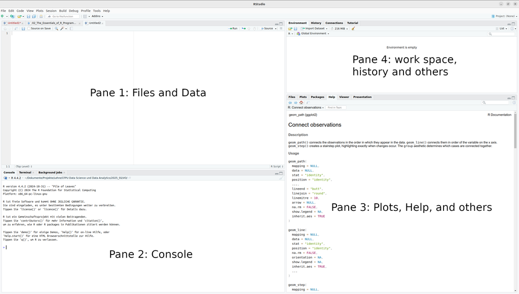

## A Tour of RStudio

- While we can write and execute code directly in the **R console** in the bottom left pane in RStudio, it is better to write all code in an **R script**.
- An R script is simply a text file that contains R code.
- In RStudio, R scripts can be opened, viewed and edited in the top left pane. To open a new R script, go to `File > New File > R script`.
- A single line of code in an R script can be sent to the console for execution via `Ctrl + Enter` (or `Cmd + Enter` on Mac).
- To write a comment in an R script, simply put a hashtag (#) in front of the comment:

```r
# This is our first R script
2 + 2 # We calculate 2 + 2
```

```
[1] 4
```

# First steps

## First steps in R – Mathematical operators

First, let’s use R as a **calculator**. We can write a calculation into our R script and R will give us the result, when the code is executed:

```r
2 + 3 # Addition
```

```
[1] 5
```

```r
2 - 4 # Subtraction
```

```
[1] -2
```

```r
3 * 4 # Multiplication
```

```
[1] 12
```

```r
4 / 2 # Division
```

```
[1] 2
```

```r
3^3 # Exponentiation
```

```
[1] 27
```

```r
(2 + 3)*(3 + 4) # Bracketing
```

```
[1] 35
```

```r
2^(3 + 4/2)*4 # All together
```

```
[1] 128
```

## First steps in R – Relational and logical operators

We can also perform comparisons using R:

```r
3 < 5
```

```
[1] TRUE
```

```r
3 > 5
```

```
[1] FALSE
```

```r
3 <= 3
```

```
[1] TRUE
```

```r
3 >= 5
```

```
[1] FALSE
```

```r
3 == 5 # Attention for the double equal sign!
```

```
[1] FALSE
```

```r
3 != 5
```

```
[1] TRUE
```

With the help of `&` and `|`, we can also carry out `AND` and `OR` operations:

```r
(3 == 5) | (5 == 5) # OR
```

```
[1] TRUE
```

```r
(3 == 5) & (5 == 5) # AND
```

```
[1] FALSE
```

## First steps in R – Functions

R comes with many functions that you can use to perform tasks from simple to sophisticated. Functions have **inputs** (aka **arguments**) that you pass into them and **outputs** (aka **return values**) that they give back. Functions are fundamental to how R works.

Let’s see an example. Say, we want to round the number 5.293586 to two decimal digits. Fortunately, there is a function in R called `round`. But how do we use it?

To find out, we can bring up the R help, which provides documentation for every function in R, by typing `?` and the name of the function into the console:

```r
?round
```

## First steps in R – Functions

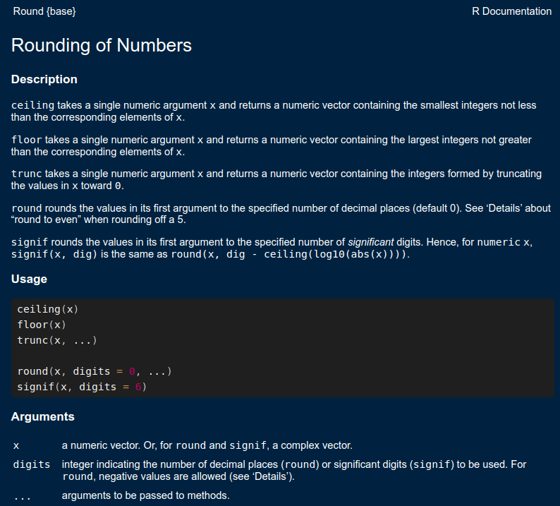

## First steps in R – Functions

```r
round(5.293586, 2)
```

```
[1] 5.29
```

Generally, we can use the `args` function to see the arguments that a function takes. For example, let’s say, we wanted to simulate someone throwing a regular die, i.e. randomly **sample** numbers from 1 to 6. Luckily, there is an R function called `sample`. Let’s inspect it.

```r
args(sample)
```

```
function (x, size, replace = FALSE, prob = NULL)
NULL
```

To find out more information on what these arguments actually mean, let’s consult the documentation again:

```r
?sample
```

## First steps in R – Functions

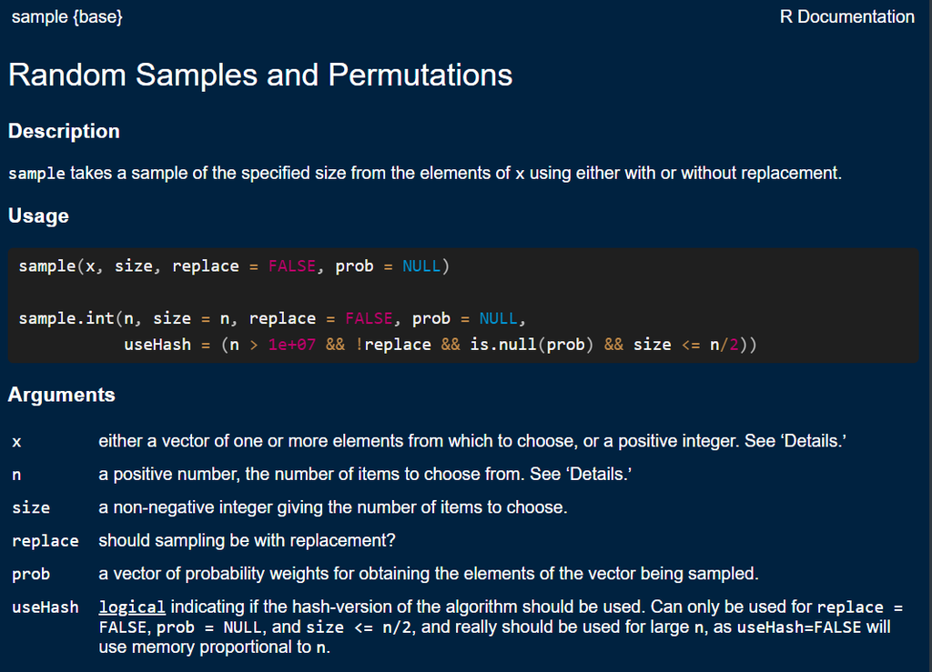

## First steps in R – Functions

So, to simulate 20 throws of a regular die, we have to use the function like this:

```r
sample(6, 20, replace = TRUE)
```

```
 [1] 1 5 1 1 2 4 2 2 1 4 1 5 6 4 2 2 3 1 1 3
```

Note that we can give the arguments to the function

- in the order that they are given in the documentation (then they do not need to be named).
- by explicitly naming them when calling the function (then the order does not matter).
- by mixing unnamed and named arguments (like we have done here).

Let’s see another example of this.

## First steps in R – Functions

Let’s say, we wanted to compute the base 2 logarithm of 10. For this, we need the `log` function in R:

```r
args(log)
```

```
function (x, base = exp(1))
NULL
```

So, based on the three options given on the previous slide, all of the following three ways of calling `log` lead to the correct result:

```r
log(10, 2)
```

```
[1] 3.321928
```

```r
log(base = 2, x = 10)
```

```
[1] 3.321928
```

```r
log(10, base = 2)
```

```
[1] 3.321928
```

However, options 1 and 3 are preferable, as switching the order of arguments tends to make code less easily readable for others (which could be yourself in the future…)

## First steps in R – Variables and assignment

Let’s say, you were given the task to solve the quadratic equation

$$3x^2 - 5x - 1 = 0$$

You will remember from back in your high school days that we can use the “midnight formula” for this:

$$x_{1/2} = \frac{-b \pm \sqrt{b^2 - 4ac}}{2a}$$

With R, we can easily compute this of course:

```r
(-(-5) + sqrt((-5)^2 - 4*3*(-1)))/(2*3)
```

```
[1] 1.847127
```

```r
(-(-5) - sqrt((-5)^2 - 4*3*(-1)))/(2*3)
```

```
[1] -0.1804604
```

## First steps in R – Variables and assignment

Next, we are given another quadratic equation

$$4x^2 - 8x + 2 = 0$$

To compute the solution with R, we would have to replace every occurrence of $a$, $b$ and $c$, so in total, we would have to make 10 replacements to get both solutions. That’s too cumbersome and error-prone…

Instead, we can define **variables** $a$, $b$ and $c$ and simply **assign** different values to them every time we have to solve a quadratic equation. Such assignments happen in R with the help of the assignment operator `<-` (read it as “gets”):

```r
a <- 3
b <- -5
c <- -1
# Note that nothing is printed to the console when assigning variables.
```

Now, we can write expressions using these variables like we would in maths.

## First steps in R – Variables and assignment

```r
(-b + sqrt(b^2 - 4*a*c))/(2*a)
```

```
[1] 1.847127
```

```r
(-b - sqrt(b^2 - 4*a*c))/(2*a)
```

```
[1] -0.1804604
```

Now, to compute the solution to the second quadratic equation, we simply re-define the variables `a`, `b` and `c` and then evaluate the same expression again:

```r
a <- 4
b <- -8
c <- 2

(-b + sqrt(b^2 - 4*a*c))/(2*a)
```

```
[1] 1.707107
```

```r
(-b - sqrt(b^2 - 4*a*c))/(2*a)
```

```
[1] 0.2928932
```

Note that R is **case-sensitive**, so it now knows variables with names `a`, `b` and `c`, but it does not know `A`, `B` or `C`:

```r
A
```

```
Error: Objekt 'A' nicht gefunden
```

## First steps in R – Variables and assignment

With assignments, we are creating **objects** in R that are saved and can be referenced by the names that we give them (e.g. `a`, `b` and `c`). Creating **objects** like this will make them appear in the work space in pane 4 of the RStudio window:

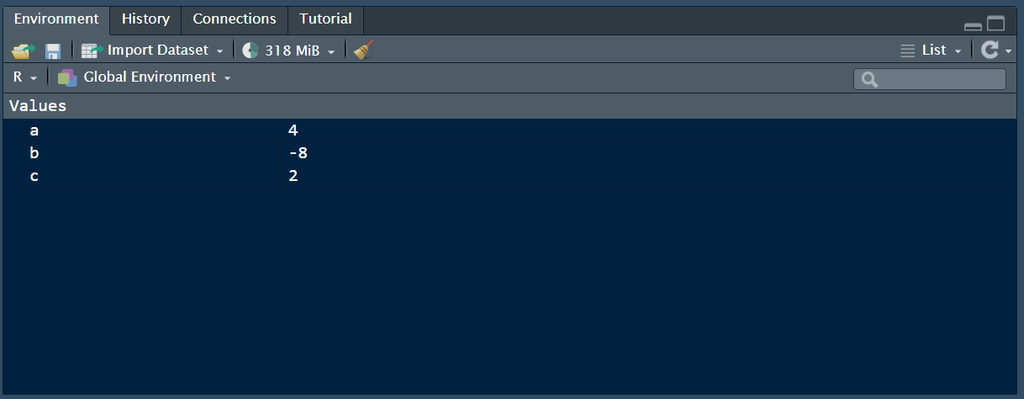

We can also see all variables currently defined in the work space by typing `ls()`:

```r
ls()
```

```
[1] "a" "b" "c"
```

## First steps in R – User-defined functions

With the assignment operator, we can also define our own functions of course! To define a function, we need a **function name**, **arguments**, a **function body** and a **return value**:

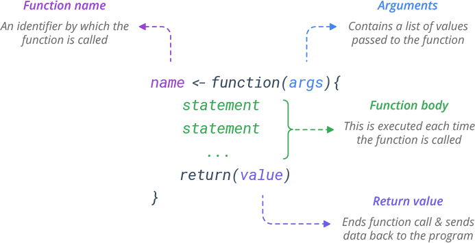

## First steps in R – User-defined functions

Consider the following example: say we want to write a function called `quadratic_solver` (function **name**) that gives us the solution to any quadratic equation. It needs input **arguments** `a`, `b` and `c` and should **return** the two solutions. In the function **body**, the two solutions should be computed for the three inputs. So, we could create the function as follows:

```r
quadratic_solver <- function(a, b, c){
  sol_1 <- (-b + sqrt(b^2 - 4*a*c))/(2*a)
  sol_2 <- (-b - sqrt(b^2 - 4*a*c))/(2*a)
  return(c(sol_1, sol_2))
}
```

Now, we can use this function like any other:

```r
quadratic_solver(3, -5, -1)
```

```
[1]  1.8471271 -0.1804604
```

```r
quadratic_solver(4, -8, 2)
```

```
[1] 1.7071068 0.2928932
```

# Data types and Data structures

## Data types in R

In R, the following six **data types** are available:

- double (i.e., double precision floating-point number – R lingo for real number),
- integer,
- character (sometimes referred to as string),
- logical/boolean (can only take values `TRUE` or `FALSE`),
- complex (as in complex numbers, not relevant for us),
- raw (not relevant for us),

We can find the type of an object using the function `typeof`. We can verify, whether an object is of a certain `<type>` by using the function `is.<type>`. Let’s see some examples.

## Double

By default, R will save any number that you type in as a `double`.

```r
a <- 2
b <- 3.141593

typeof(a)
```

```
[1] "double"
```

```r
typeof(b)
```

```
[1] "double"
```

```r
is.double(a)
```

```
[1] TRUE
```

```r
is.double(b)
```

```
[1] TRUE
```

Together with `integer`, the data type `double` is one of the two `numeric` types, i.e. representing numbers:

```r
is.numeric(a)
```

```
[1] TRUE
```

```r
is.numeric(b)
```

```
[1] TRUE
```

## Integer

**Integers** (whole numbers) are (positive or negative) numbers that can be written without a decimal component. This data type is more important for developers as it saves memory (compared to doubles). To specify an integer over a double, the number has to be followed by an uppercase `L`:

```r
i <- 10L

typeof(i)
```

```
[1] "integer"
```

```r
is.integer(i)
```

```
[1] TRUE
```

```r
is.double(i)
```

```
[1] FALSE
```

(Pure) integers are also `numeric` of course:

```r
is.numeric(i)
```

```
[1] TRUE
```

## Character

Text data is represented in R with the help of the `character` data type. To demarcate a string of characters, you can use double or single quotes (`""` or `''`).

```r
letter <- "a"
w <- 'Hello, world.'

typeof(letter)
```

```
[1] "character"
```

```r
typeof(w)
```

```
[1] "character"
```

```r
is.character(letter)
```

```
[1] TRUE
```

```r
is.character(w)
```

```
[1] TRUE
```

Of course, `character` objects are *not* numeric.

```r
is.numeric(letter)
```

```
[1] FALSE
```

```r
is.numeric(w)
```

```
[1] FALSE
```

## Logical

When working with relational operators, we already saw a couple of instances of the `logical` data type. It can only take the values TRUE and FALSE. Negation of a `logical` object (i.e. saying **NOT**) can be achieved with the help of the `!` operator:

```r
bigger <- 5 > 3

typeof(bigger)
```

```
[1] "logical"
```

```r
is.logical(bigger)
```

```
[1] TRUE
```

```r
!bigger
```

```
[1] FALSE
```

`Logical` objects are also *not* numeric.

```r
is.numeric(bigger)
```

```
[1] FALSE
```

```r
is.numeric(!bigger)
```

```
[1] FALSE
```

## Type coercion

We can **coerce** an object to be of a certain `<type>` by using the function `as.<type>`. This process is called **type coercion**.

In some cases, this is very intuitive…

```r
as.double("2.71828")
```

```
[1] 2.71828
```

```r
as.integer("10")
```

```
[1] 10
```

```r
as.numeric("10") # creates a double
```

```
[1] 10
```

```r
as.character(42)
```

```
[1] "42"
```

… in others, maybe not so much…

```r
as.integer(2.9) # returns the closest smaller integer
```

```
[1] 2
```

```r
as.logical(2.9) # returns TRUE for any number other than 0
```

```
[1] TRUE
```

```r
as.logical(0)
```

```
[1] FALSE
```

## Special values

Non-sensical attempts at coercion are translated as `NA` (not available).

```r
as.numeric("Hello, world.")
```

```
[1] NA
```

```r
as.logical("5")
```

```
[1] NA
```

`NA` is one of four **special values**. While `NA` can occur for any data type, the other three can only occur for `numeric` data types. These are:

- `Inf`: positive infinity
- `-Inf`: negative infinity
- `NaN`: not a number

While they are not technically numbers, these special values still follow logical rules when applying mathematical operations on them.

## Special values

```r
2 / 0
```

```
[1] Inf
```

```r
2 / 0 + 2 / 0
```

```
[1] Inf
```

```r
-2 / 0
```

```
[1] -Inf
```

```r
-2 / 0 - 2 / 0
```

```
[1] -Inf
```

```r
0 / 0
```

```
[1] NaN
```

```r
2 / 0 - 2 / 0
```

```
[1] NaN
```

```r
- 1 / 0 + 2 / 0
```

```
[1] NaN
```

Unlike `NaN`, `NA`s are genuinely **unknown** values. Nevertheless, they also have their logical rules. Consider the following example. Let’s think about why each of the following four results makes sense:

```r
TRUE | NA
```

```
[1] TRUE
```

```r
TRUE & NA
```

```
[1] NA
```

```r
FALSE | NA
```

```
[1] NA
```

```r
FALSE & NA
```

```
[1] FALSE
```

Note: all special values have their own `is.<special>` function to check for them, i.e. `is.na`, `is.nan` and `is.infinite`.

## Data structures

- On top of these six basic **data types**, R builds several kinds of more complex **data structures** in different ways to suit different applications that are regularly encountered in the statistics / data science context.
- We will use the following regularly and hence discuss them in more detail:
  - (Atomic) `vector`
  - `list`
  - `matrix`
  - `data.frame`
  - `factor`
  - `Date`

## Atomic vector

An **atomic vector** is a simple vector of values of **one data type**. Values can be **concatenated** together into a vector using the `c` function. For example:

```r
x <- c(3, 4, 5)
x
```

```
[1] 3 4 5
```

Since we have filled the vector `x` with values of type `double`, it will itself also be of type `double`. It has several attributes / characteristics such as `length`:

```r
typeof(x)
```

```
[1] "double"
```

```r
is.double(x)
```

```
[1] TRUE
```

```r
length(x)
```

```
[1] 3
```

We can also assign names to the vector elements:

```r
names(x) <- c("a", "b", "c")
x
```

```
a b c
3 4 5
```

## Atomic vector

What happens if we try to create a vector with data of different types?

```r
y <- c(1, "a", TRUE)
y
```

```
[1] "1"    "a"    "TRUE"
```

When we attempt to combine different types, R will **coerce** the data in a fixed order, namely `character` $\to$ `double` $\to$ `integer` $\to$ `logical`, i.e. if any data of a higher-order type appears in the vector creation, the vector will be of that type:

```r
typeof(y)
```

```
[1] "character"
```

So, what will be the type of the following vector?

```r
z <- c(0L, 1L, 2, TRUE)
```

As the `2` is of type `double`, this is the highest-order type in the vector, so:

```r
typeof(z)
```

```
[1] "double"
```

## Working with vectors – Vectorization

Most operations in R are **vectorized**, which means they are (automatically) performed element by element:

```r
x
```

```
a b c
3 4 5
```

```r
x^2
```

```
 a  b  c
 9 16 25
```

```r
log(x)
```

```
       a        b        c
1.098612 1.386294 1.609438
```

This also applies when we want to add / subtract / multiply / divide two vectors **element-wise**:

```r
y <- c(5, 12, 13)
x + y
```

```
 a  b  c
 8 16 18
```

```r
x * y
```

```
 a  b  c
15 48 65
```

## Working with vectors – Vectorization

If two vectors are of different lengths, then R recycles the smaller one to allow operations like the following:

```r
x <- c(1, 2, 3)
y <- c(10, 20, 30, 40, 50, 60)
x + 2
```

```
[1] 3 4 5
```

```r
x + y
```

```
[1] 11 22 33 41 52 63
```

However, **beware of recycling**:

```r
x <- c(1, 2, 3)
y <- c(10, 20, 30, 40, 50, 60, 70)
x + y
```

```
[1] 11 22 33 41 52 63 71
```

## Working with vectors – Sequences

To create vectors that are **sequences**, there is a very useful R function called `seq`:

```r
seq(1, 10)
```

```
 [1]  1  2  3  4  5  6  7  8  9 10
```

```r
seq(2, 20, by = 2)
```

```
 [1]  2  4  6  8 10 12 14 16 18 20
```

```r
seq(1.2, 0.2, by = -0.1)
```

```
 [1] 1.2 1.1 1.0 0.9 0.8 0.7 0.6 0.5 0.4 0.3 0.2
```

Sequences of **consecutive integers** – like the first one we saw – are particularly frequently needed in (R) programming. For this reason, there is a short-hand notation (“syntactic sugar”) to create sequences of that kind, which is `start_value:end_value`:

```r
s <- 1:10
typeof(s)
```

```
[1] "integer"
```

```r
s
```

```
 [1]  1  2  3  4  5  6  7  8  9 10
```

## Working with vectors – Subsetting

If we want to extract or replace elements of a vector, you can use **square brackets** `[]` with logical or numeric input:

```r
alphabet <- c("a", "b", "c", "d", "e", "f", "g", "h", "i", "j", "k", "l", "m", "n",
              "o", "p", "q", "r", "s", "t", "u", "v", "w", "x", "y", "z")
# Numeric subsetting
alphabet[1:3] # first three
```

```
[1] "a" "b" "c"
```

```r
alphabet[3:1] # first three in descending order
```

```
[1] "c" "b" "a"
```

```r
alphabet[c(2, 4)] # second and fourth
```

```
[1] "b" "d"
```

```r
alphabet[-(1:10)] # all except the first 10
```

```
 [1] "k" "l" "m" "n" "o" "p" "q" "r" "s" "t" "u" "v" "w" "x" "y" "z"
```

```r
alphabet[5] <- "E" # replace the fifth element by a capital E

# Logical subsetting
alphabet == "E"
```

```
 [1] FALSE FALSE FALSE FALSE  TRUE FALSE FALSE FALSE FALSE FALSE FALSE FALSE
[13] FALSE FALSE FALSE FALSE FALSE FALSE FALSE FALSE FALSE FALSE FALSE FALSE
[25] FALSE FALSE
```

```r
alphabet[alphabet == "E"]
```

```
[1] "E"
```

## Working with vectors – Subsetting

We can also use the `which` function to turn a logical vector into an integer vector that gives the indices of all elements in the vector that are `TRUE`:

```r
which(alphabet == "E")
```

```
[1] 5
```

```r
alphabet[which(alphabet == "E")]
```

```
[1] "E"
```

With the `%in%` operator, we can check whether elements of the vector are contained **in** another vector:

```r
alphabet %in% c("x", "y", "z")
```

```
 [1] FALSE FALSE FALSE FALSE FALSE FALSE FALSE FALSE FALSE FALSE FALSE FALSE
[13] FALSE FALSE FALSE FALSE FALSE FALSE FALSE FALSE FALSE FALSE FALSE  TRUE
[25]  TRUE  TRUE
```

```r
which(alphabet %in% c("x", "y", "z"))
```

```
[1] 24 25 26
```

```r
alphabet[alphabet %in% c("x", "y", "z")]
```

```
[1] "x" "y" "z"
```